**Download** this file as a Jupyter Notebook@ http://54.243.252.9/ce-3372-webroot/2-Exercises/ES9/ES9.ipynb

# ES-9 Solution Sketch

Copyright © 2022 Theodore G. Cleveland

## Purpose:

Construct a design storm hyetograph

## Problem Statement

Assume that Somewhere USA is to be located in Harris County.

### Part 1 (Check Syllabus/BB for Due Date)

1. Using the NOAA-PFDS estimate the rainfall depth for a 10-year, 6-hour storm in Harris county.
2. Using the SCS Tabulation or Texas Empirical Hyetographs, construct from the 10-year, 6-hour storm a design hyetograph at 15 minute intervals.

[figure not shown]

| Figure 1. Screen capture PFDS for Harris Co. Interrogation |
| --- |

[figure not shown]

| Figure 2. Screen capture Texas Hyetograph Tool |
| --- |

The actual numbers are captured below:

```python
import pandas
hyetograph = pandas.DataFrame([[0,0,0.000],
[15,0.25,0.686],
[30,0.50,1.416],
[45,0.75,1.955],
[60,1.00,2.361],
[75,1.25,2.668],
[90,1.50,2.901],
[105,1.75,3.080],
[120,2.00,3.226],
[135,2.25,3.354],
[150,2.50,3.477],
[165,2.75,3.606],
[180,3.00,3.749],
[195,3.25,3.910],
[210,3.50,4.088],
[225,3.75,4.283],
[240,4.00,4.489],
[255,4.25,4.700],
[270,4.50,4.910],
[285,4.75,5.113],
[300,5.00,5.303],
[315,5.25,5.476],
[330,5.50,5.629],
[345,5.75,5.762],
[360,6.00,6.010]])
hyetograph.columns =["minutes","hours","acc_depth_inches"]
hyetograph.head()
```

|  | minutes | hours | acc_depth_inches |
| --- | --- | --- | --- |
| 0 | 0 | 0.00 | 0.000 |
| 1 | 15 | 0.25 | 0.686 |
| 2 | 30 | 0.50 | 1.416 |
| 3 | 45 | 0.75 | 1.955 |
| 4 | 60 | 1.00 | 2.361 |

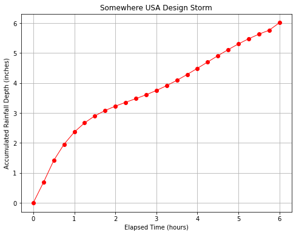

```python
# plot the hyetograph as per ENGR 1330
from matplotlib import pyplot as plt
mydata = plt.figure(figsize = (8,6)) # build a drawing canvass from figure class; aspect ratio 4x3
plt.plot(hyetograph["hours"],hyetograph["acc_depth_inches"], c='red', marker='o',linewidth=1) # basic line plot
plt.xlabel('Elapsed Time (hours)') # label the x-axis
plt.ylabel('Accumulated Rainfall Depth (inches)') # label the y-axis, notice the LaTex markup
#plt.legend(['series1','series2...']) # legend for each series
plt.title('Somewhere USA Design Storm') # make a plot title
plt.grid() # display a grid
plt.show() # display the plot
```

```python
# prep the data for cut-and-paste into SWMM
print(hyetograph[["hours","acc_depth_inches"]].to_string(index=False))
```

```
 hours  acc_depth_inches
  0.00             0.000
  0.25             0.686
  0.50             1.416
  0.75             1.955
  1.00             2.361
  1.25             2.668
  1.50             2.901
  1.75             3.080
  2.00             3.226
  2.25             3.354
  2.50             3.477
  2.75             3.606
  3.00             3.749
  3.25             3.910
  3.50             4.088
  3.75             4.283
  4.00             4.489
  4.25             4.700
  4.50             4.910
  4.75             5.113
  5.00             5.303
  5.25             5.476
  5.50             5.629
  5.75             5.762
  6.00             6.010
```

### Part 2 (Check Syllabus/BB for Due Date)

1. Apply the hyetograph to a 1 sq.mi. watershed in SWMM using program defaults for the drainage area description (except set the length to 5280 ft.), use the CN runoff generation model in SWMM with CN=98. Simulate 24 hours of runoff with reporting every 15 minutes.

[figure not shown]

| Figure 3. Screen capture SWMM set-up raingage (named PuffyTheCloud) |
| --- |

[figure not shown]

[output not shown]

## Deliverables:

A brief report with your solution, showing the rainfall depth(s), hyetograph (on 15-minute intervals) for Part 1 and the SWMM generated hydrograph for Part 2.

A screen capture of the SWMM output is sufficient for Part 2 **Do not submit a SWMM output file**

## References

1. NOAA Precipitation-Frequency Data Server https://hdsc.nws.noaa.gov/hdsc/pfds/
2. Intensity Interpolater (for use with PFDS results) for non-tabulated durations. http://54.243.252.9/toolbox/ordinarytools/IntensityInterpolate/IntensityInterpolate.html 2.Williams-Sether, T., Asquith, W.H., Thompson, D.B., Cleveland, T.G., and X. Fang. 2004. Empirical, Dimensionless, Cumulative-Rainfall Hyetographs for Texas. U.S.Geological Survey Scientific Investigations Report 2004-5075, 138p. https://75.3.84.227/documents/about-me/MyWebPapers/project_reports/SIR_2004_5075/sir2004-5075.pdf
3. Neale, C.M., Tay, C.C., Herrmann, G.R., and Cleveland, T.G. 2015. "TXHYETO.XLS a tool to facilitate use of Texas-Specific Hyetographs for design storm modeling." Proceedings of ASCE World Environmental and Water Resources Congress, ASCE-EWRI, Austin, TX. May 17-21, 2015. pp. 241-254.https://75.3.84.227/documents/about-me/MyWebPapers/conference_papers/2015_ASCE_CAROLINE/
4. TXHYETO (spreadsheet and training video for using Texas empirical hyetographs)http://54.243.252.9/toolbox/hydrology/EBDLKUP-2015-DISTRIBUTE/
5. Rossman, L.A., 2010 STORM WATER MANAGEMENT MODEL USER’S MANUAL Version 5.0, Technical Report EPA/600/R-05/040,U.S. Environmental Protection Agency, National Risk Management Research Laboratory Cincinnati, OH 45268. http://54.243.252.9/ce-3372-webroot/3-Readings/epaswmm5_user_manual/P100ERK4.pdf
6. Rossman, L.A., 2006 STORM WATER MANAGEMENT MODEL QUALITY ASSURANCE REPORT: Dynamic Wave Flow Routing, Technical Report EPA/600/R-06/297,U.S. Environmental Protection Agency, National Risk Management Research Laboratory Cincinnati, OH 45268. http://54.243.252.9/ce-3372-webroot/3-Readings/epaswmm5_qa/SWMM5_QA.pdf
7. Gironás, J., Roesner, L.A., Davis, J. 2009 STORM WATER MANAGEMENT MODEL APPLICATIONS MANUAL , Technical Report EPA/600/R-09/000,U.S. Environmental Protection Agency, National Risk Management Research Laboratory Cincinnati, OH 45268. http://54.243.252.9/ce-3372-webroot/3-Readings/epaswmm5_user_manual/P100ERK4.pdf

[figure not shown]